# Final project

## Визуализация исходных данных

*Weekly Sales*

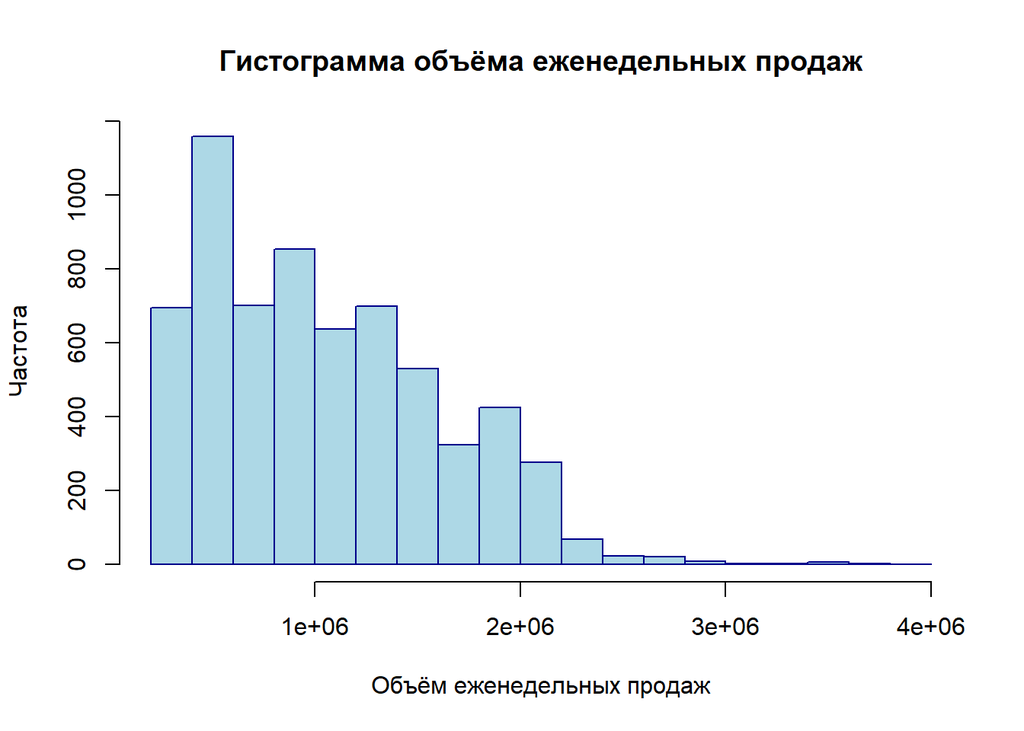

```r
hist (data$Weekly_Sales, col = "lightblue", border = "darkblue", main = "Гистограмма объёма еженедельных продаж", xlab = "Объём еженедельных продаж", ylab = "Частота")
```

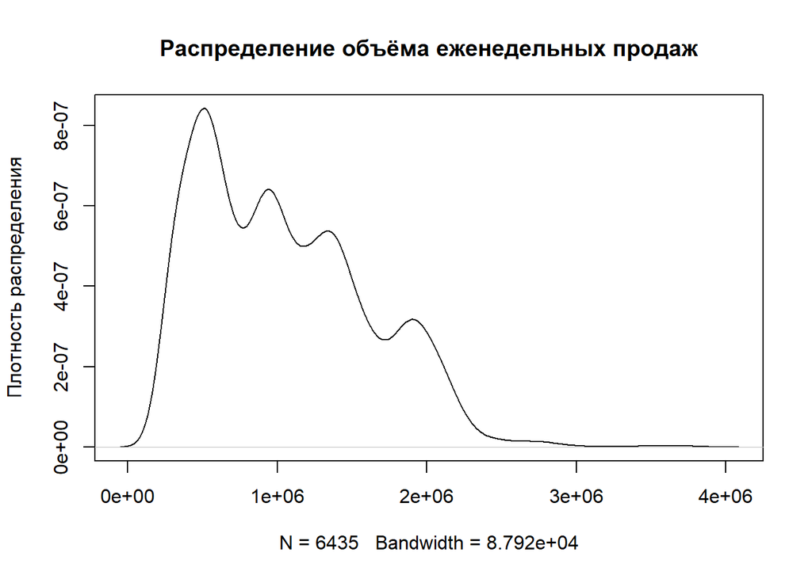

```r
plot(density(data$Weekly_Sales), main="Распределение объёма еженедельных продаж", ylab="Плотность распределения")
```

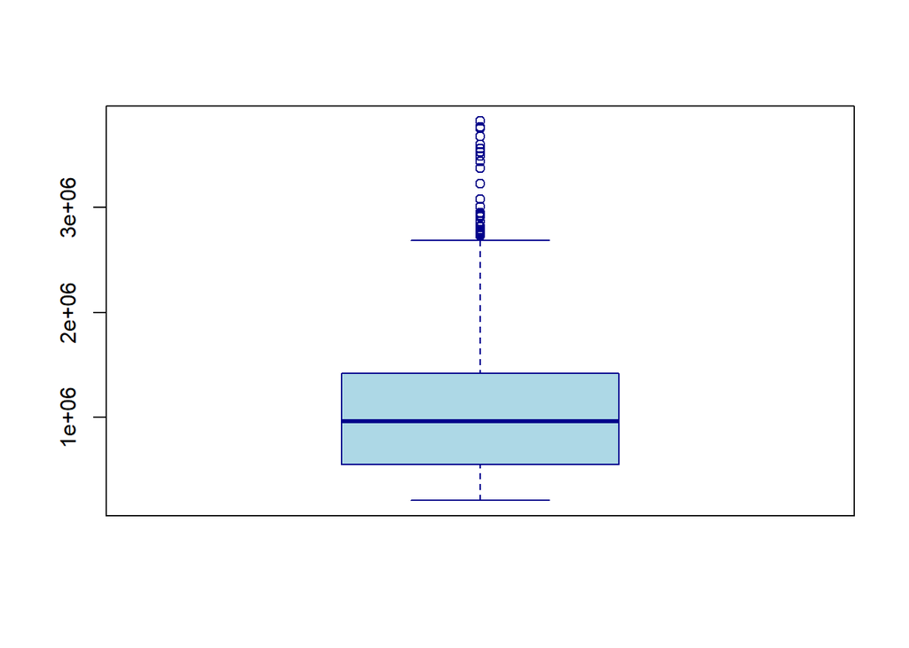

```r
boxplot(data$Weekly_Sales, col = "lightblue", border = "darkblue")
```

Распределение данных по объёму еженедельных продаж смещено влево. Это означает то, что объем еженедельных продаж зачастую был ниже 1 млн долл. США. Имеются несколько выбросов, которые значительно выше медианы.

*Temperature*

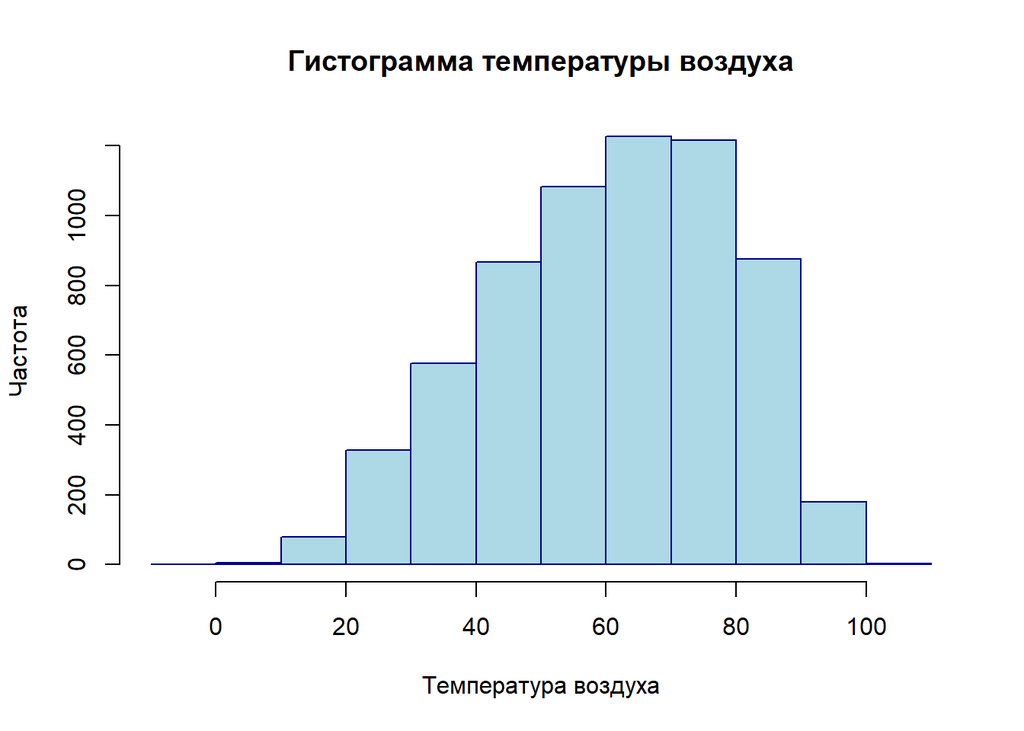

```r
hist (data$Temperature, col = "lightblue", border = "darkblue", main = "Гистограмма температуры воздуха", xlab = "Температура воздуха", ylab = "Частота")
```

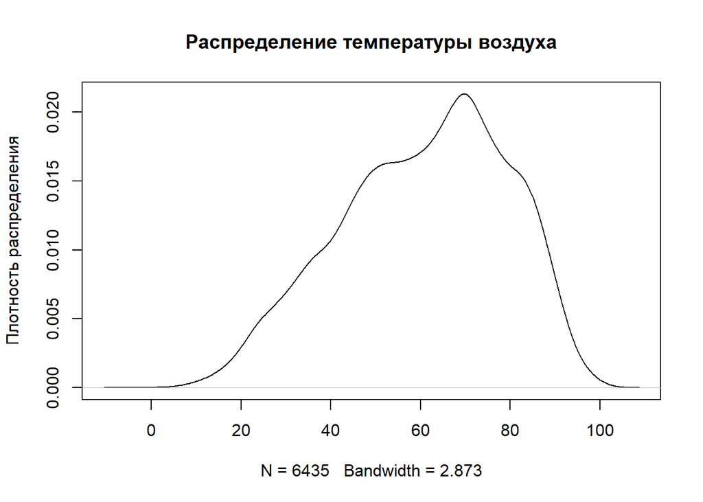

```r
plot(density(data$Temperature), main="Распределение температуры воздуха", ylab="Плотность распределения")
```

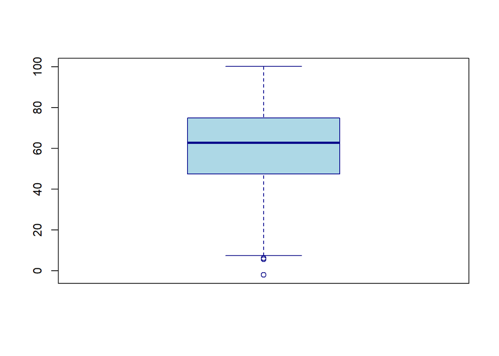

```r
boxplot(data$Temperature, col = "lightblue", border = "darkblue")
```

Распределение данных по температуры воздуха смещено вправо. В исследуемый период температура воздуха частенько была в диапазоне от 50 до 80 градусов по Фаренгейту. Имеются несколько выбросов ниже медианы.

*Fuel Price*

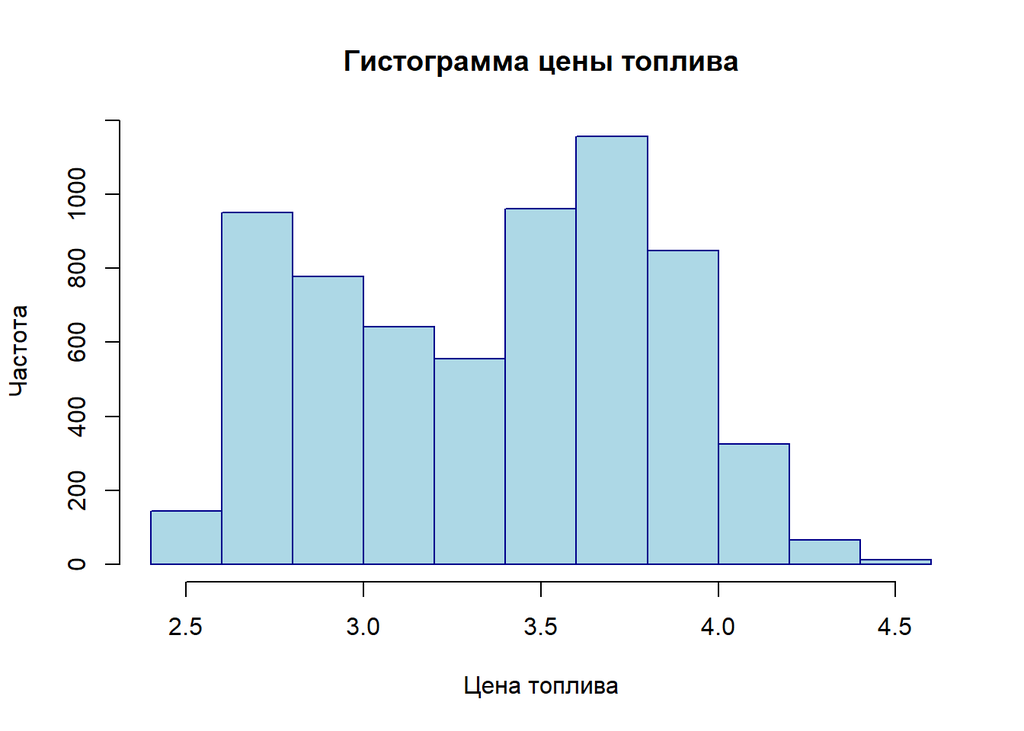

```r
hist (data$Fuel_Price, col = "lightblue", border = "darkblue", main = "Гистограмма цены топлива", xlab = "Цена топлива", ylab = "Частота")
```

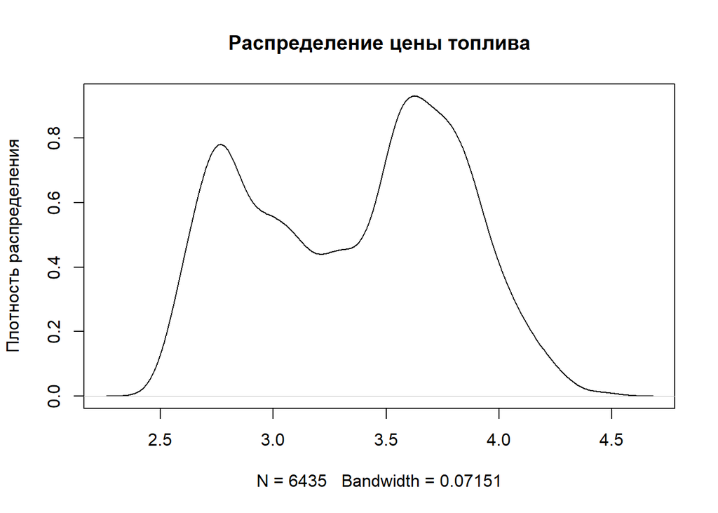

```r
plot(density(data$Fuel_Price), main="Распределение цены топлива", ylab="Плотность распределения")
```

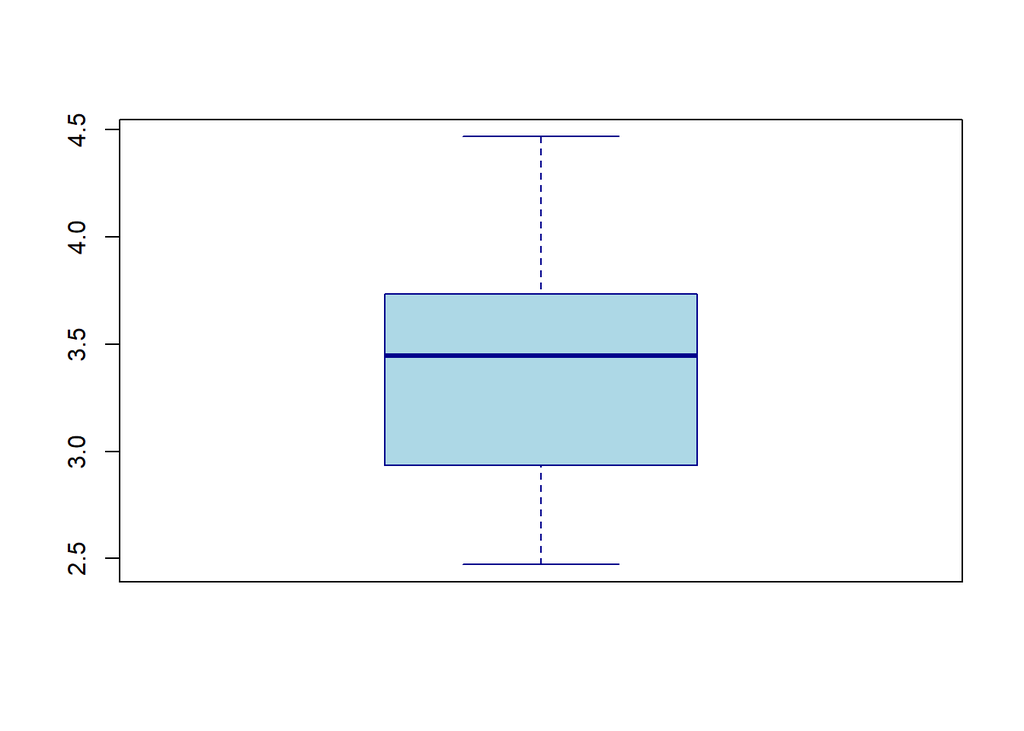

```r
boxplot(data$Fuel_Price, col = "lightblue", border = "darkblue")
```

Распределение данных по цене топлива имеет два пика. Цена топлива зачастую была в районе 3,4-3,8 долл. США. Выбросов нет.

*CPI*

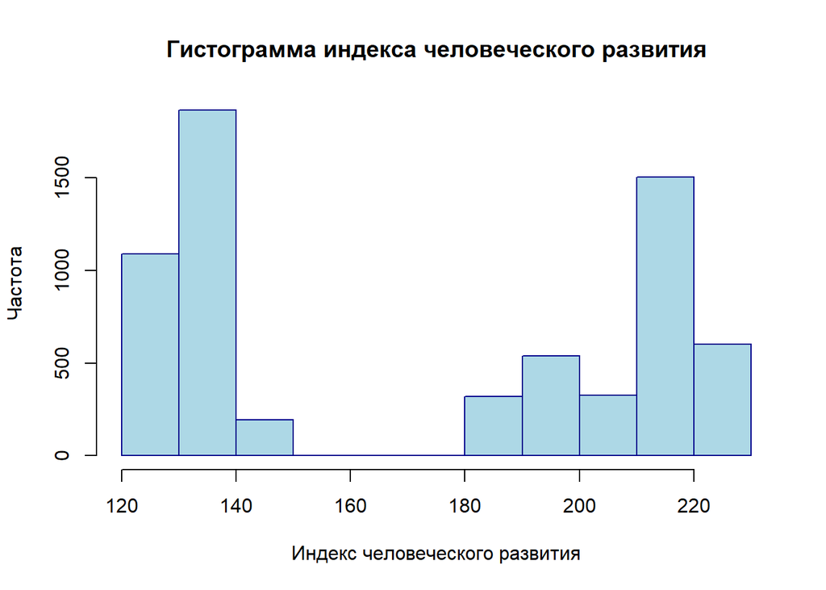

```r
hist (data$CPI, col = "lightblue", border = "darkblue", main = "Гистограмма индекса человеческого развития", xlab = "Индекс человеческого развития", ylab = "Частота")
```

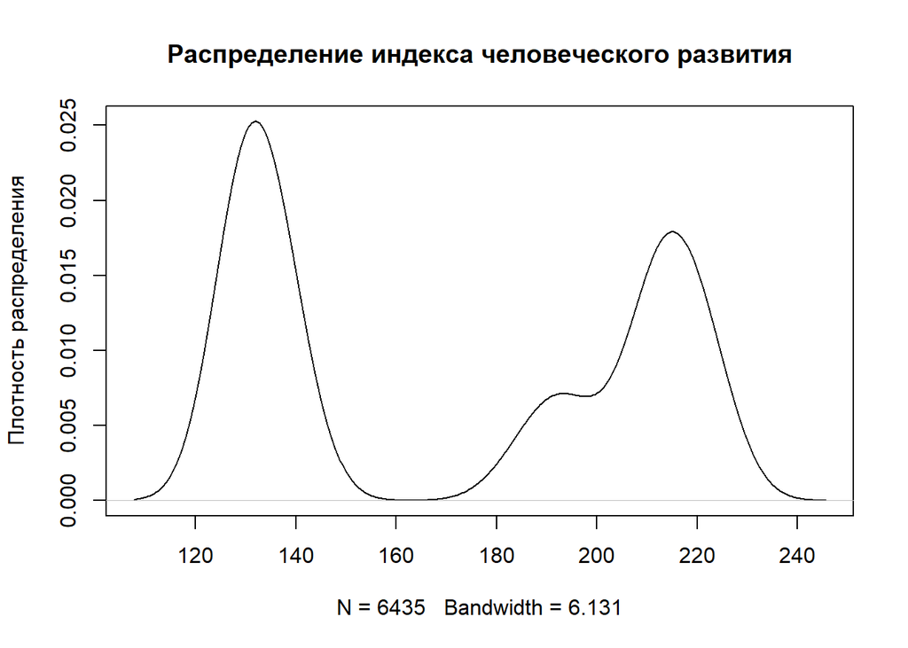

```r
plot(density(data$CPI), main="Распределение индекса человеческого развития", ylab="Плотность распределения")
```

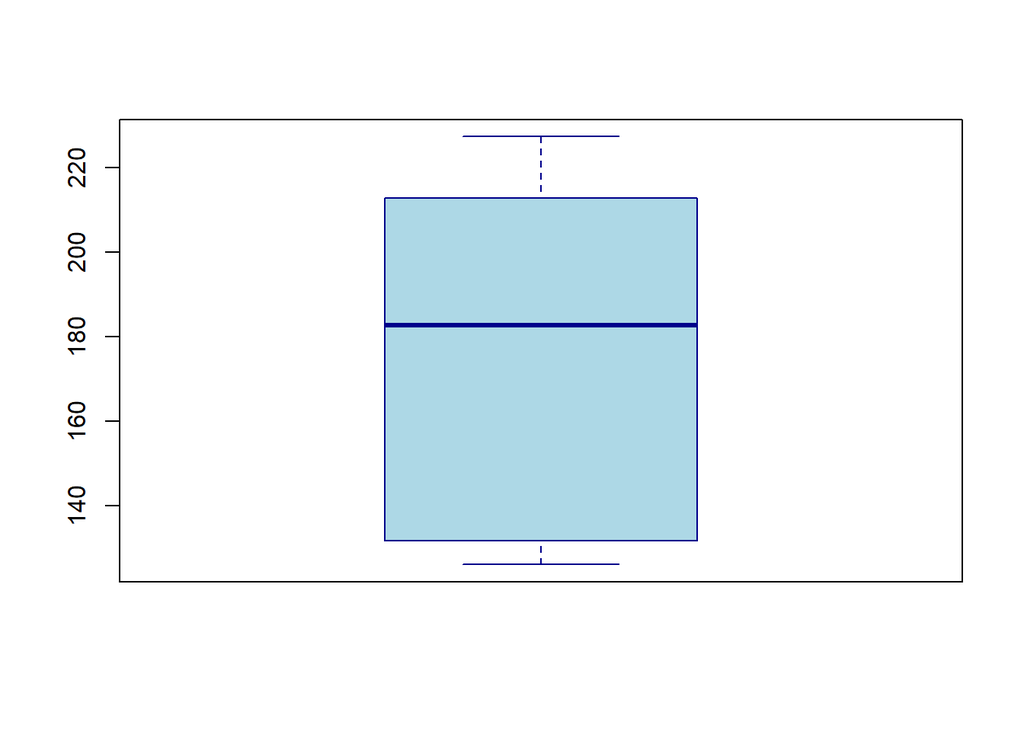

```r
boxplot(data$CPI, col = "lightblue", border = "darkblue")
```

*Unemployment*

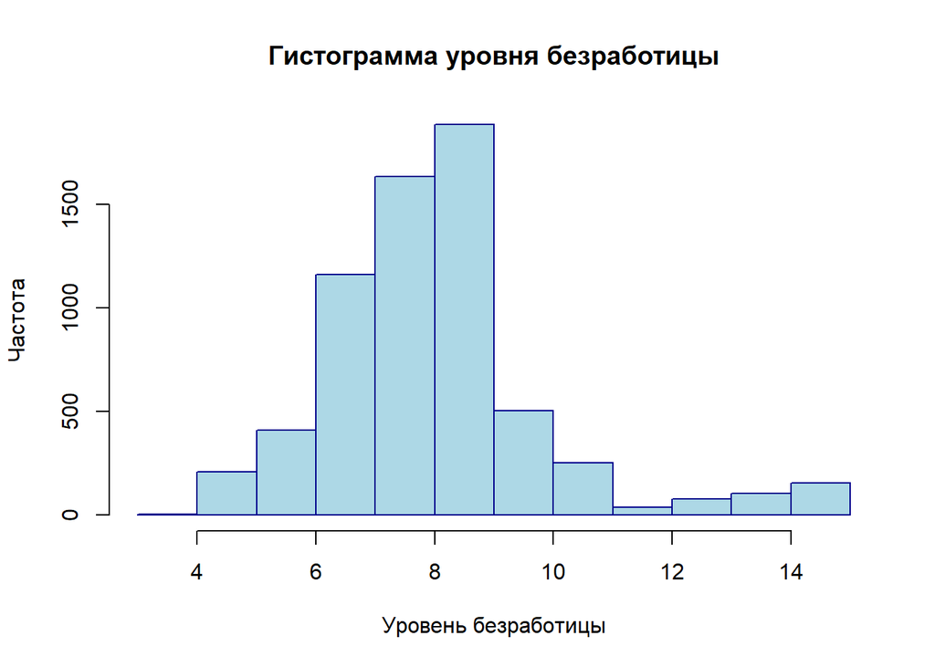

```r
hist (data$Unemployment, col = "lightblue", border = "darkblue", main = "Гистограмма уровня безработицы", xlab = "Уровень безработицы", ylab = "Частота")
```

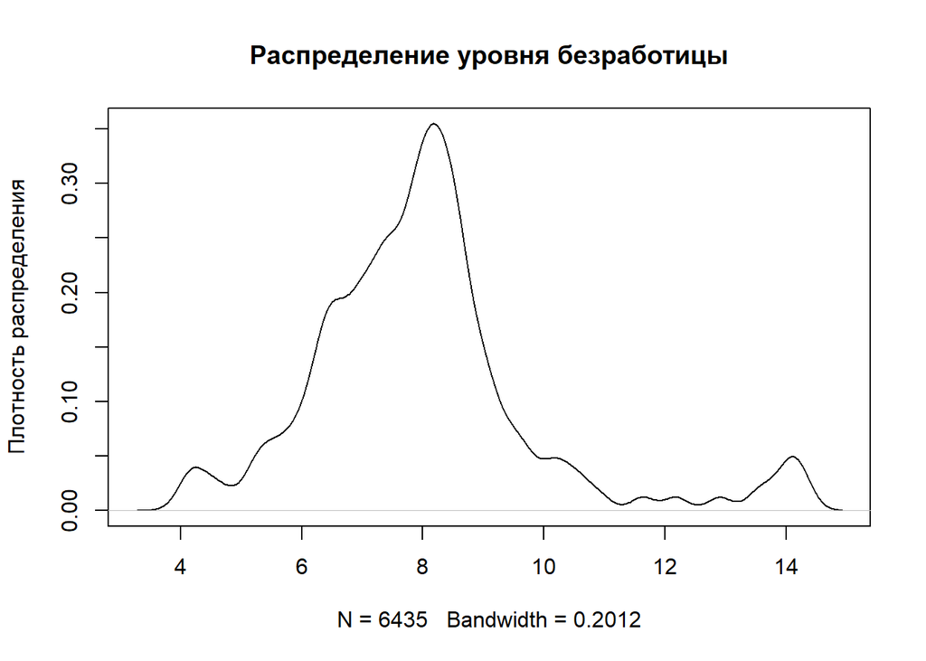

```r
plot(density(data$Unemployment), main="Распределение уровня безработицы", ylab="Плотность распределения")
```

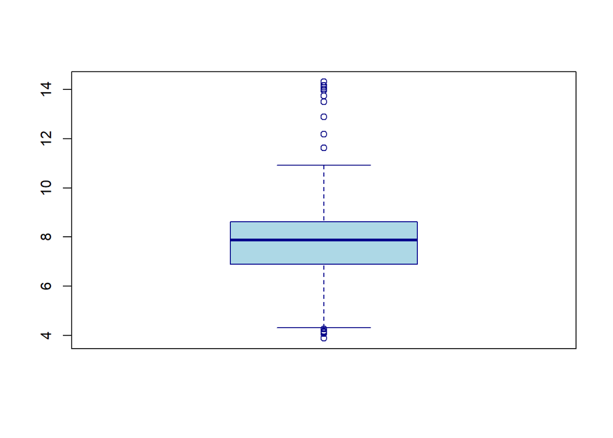

```r
boxplot(data$Unemployment, col = "lightblue", border = "darkblue")
```

Распределение данных по уровню безработицы немного смещено влево. В исследуемый период уровень безработицы чаще всего был равен 6-9%. Имеются несколько выбросов выше и ниже медианы.

## Описательная статистика

```r
summary(data)
```

```
##   Weekly_Sales      Temperature       Fuel_Price         CPI
##  Min.   : 209986   Min.   : -2.06   Min.   :2.472   Min.   :126.1
##  1st Qu.: 553350   1st Qu.: 47.46   1st Qu.:2.933   1st Qu.:131.7
##  Median : 960746   Median : 62.67   Median :3.445   Median :182.6
##  Mean   :1046965   Mean   : 60.66   Mean   :3.359   Mean   :171.6
##  3rd Qu.:1420159   3rd Qu.: 74.94   3rd Qu.:3.735   3rd Qu.:212.7
##  Max.   :3818686   Max.   :100.14   Max.   :4.468   Max.   :227.2
##   Unemployment
##  Min.   : 3.879
##  1st Qu.: 6.891
##  Median : 7.874
##  Mean   : 7.999
##  3rd Qu.: 8.622
##  Max.   :14.313
```

```r
describe(data)
```

```
##              vars    n       mean        sd    median    trimmed       mad
## Weekly_Sales    1 6435 1046964.88 564366.62 960746.04 1004198.33 631596.11
## Temperature     2 6435      60.66     18.44     62.67      61.45     20.30
## Fuel_Price      3 6435       3.36      0.46      3.44       3.36      0.56
## CPI             4 6435     171.58     39.36    182.62     170.83     60.88
## Unemployment    5 6435       8.00      1.88      7.87       7.83      1.29
##                    min        max      range  skew kurtosis      se
## Weekly_Sales 209986.25 3818686.45 3608700.20  0.67     0.05 7035.37
## Temperature      -2.06     100.14     102.20 -0.34    -0.61    0.23
## Fuel_Price        2.47       4.47       2.00 -0.10    -1.18    0.01
## CPI             126.06     227.23     101.17  0.06    -1.84    0.49
## Unemployment      3.88      14.31      10.43  1.19     2.63    0.02
```

```r
mode_function <- function(x) {
  ux <- unique(x)
  ux[which.max(tabulate(match(x, ux)))]
}
mode_Weekly_Sales <- mode_function(data$Weekly_Sales); mode_Weekly_Sales
```

```
## [1] 1643691
```

```r
mode_Temperature <- mode_function(data$Temperature); mode_Temperature
```

```
## [1] 50.43
```

```r
mode_Fuel_Price <- mode_function(data$Fuel_Price); mode_Fuel_Price
```

```
## [1] 3.638
```

```r
mode_CPI <- mode_function(data$CPI); mode_CPI
```

```
## [1] 126.4421
```

```r
mode_Unemployment <- mode_function(data$Unemployment); mode_Unemployment
```

```
## [1] 8.099
```

## Исследование закона распределения исходных данных

(Тест Шапиро-Уилка проведен не был, так как число наблюдений превышает 5000)  
*Weekly_Sales*

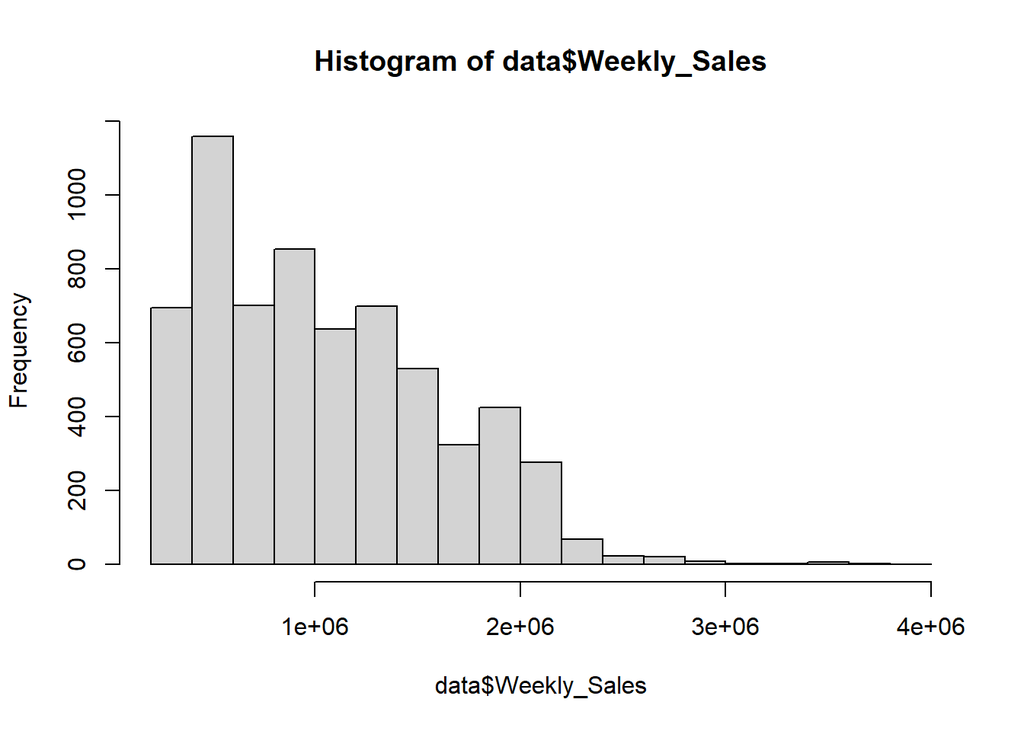

```r
hist(data$Weekly_Sales)
```

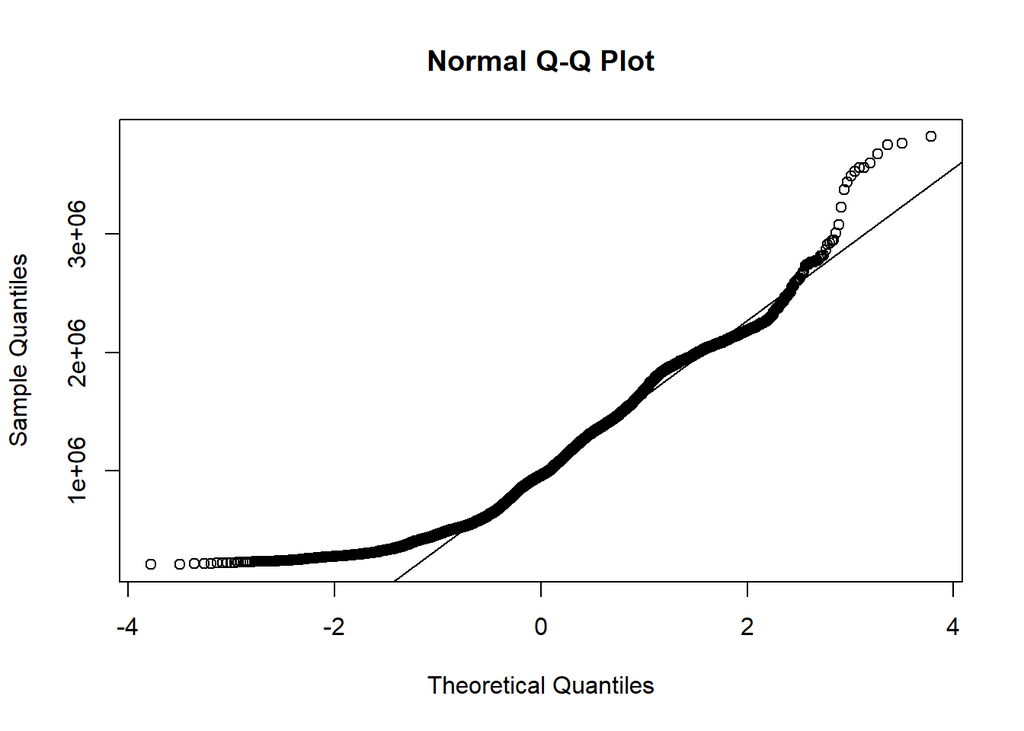

```r
qqnorm(data$Weekly_Sales)
qqline(data$Weekly_Sales)
```

```r
ks.test(data$Weekly_Sales,'pnorm')
```

```
##
##  Asymptotic one-sample Kolmogorov-Smirnov test
##
## data:  data$Weekly_Sales
## D = 1, p-value < 2.2e-16
## alternative hypothesis: two-sided
```

*Temperature*

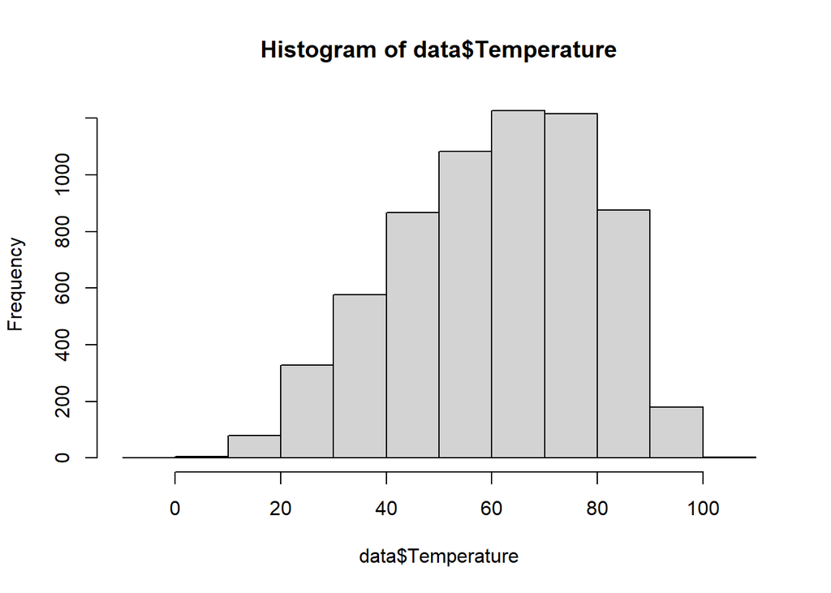

```r
hist(data$Temperature)
```

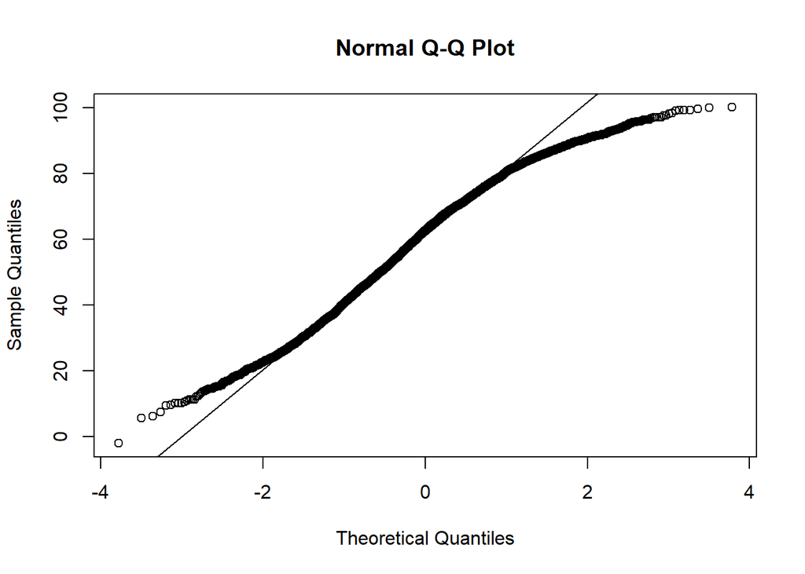

```r
qqnorm(data$Temperature)
qqline(data$Temperature)
```

```r
ks.test(data$Temperature,'pnorm')
```

```
##
##  Asymptotic one-sample Kolmogorov-Smirnov test
##
## data:  data$Temperature
## D = 0.99984, p-value < 2.2e-16
## alternative hypothesis: two-sided
```

Визуально можно предположить, что показатели температуры воздуха подчиняются нормальному распределению. Тест Колмогорова-Смирнова: так как $p_{value}<2.2e−16$, что меньше, чем $α=0.05$, то предполагается, что показатели температуры воздуха не распределены нормально.  
*Fuel Price*

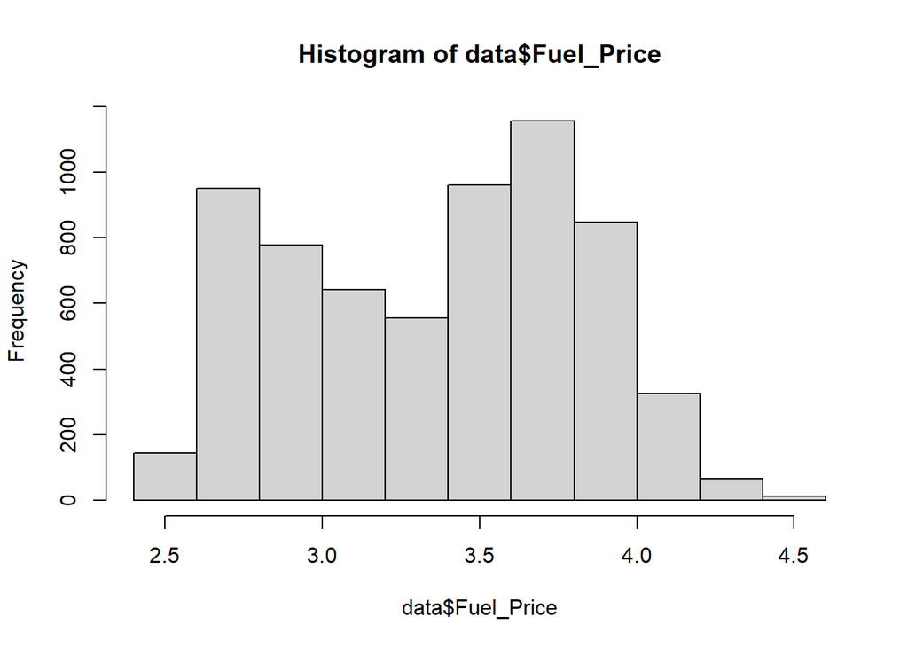

```r
hist(data$Fuel_Price)
```

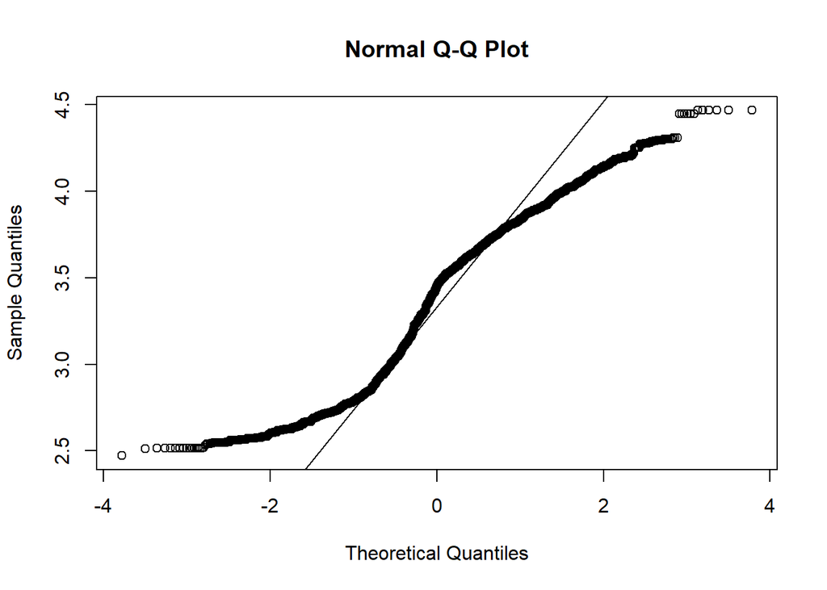

```r
qqnorm(data$Fuel_Price)
qqline(data$Fuel_Price)
```

```r
ks.test(data$Fuel_Price,'pnorm')
```

```
##
##  Asymptotic one-sample Kolmogorov-Smirnov test
##
## data:  data$Fuel_Price
## D = 0.99386, p-value < 2.2e-16
## alternative hypothesis: two-sided
```

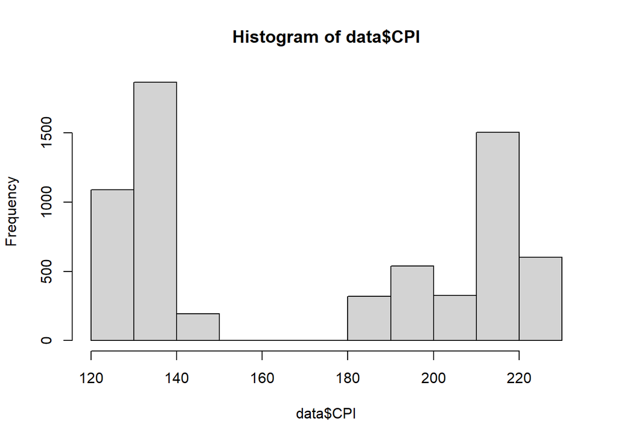

```r
hist(data$CPI)
```

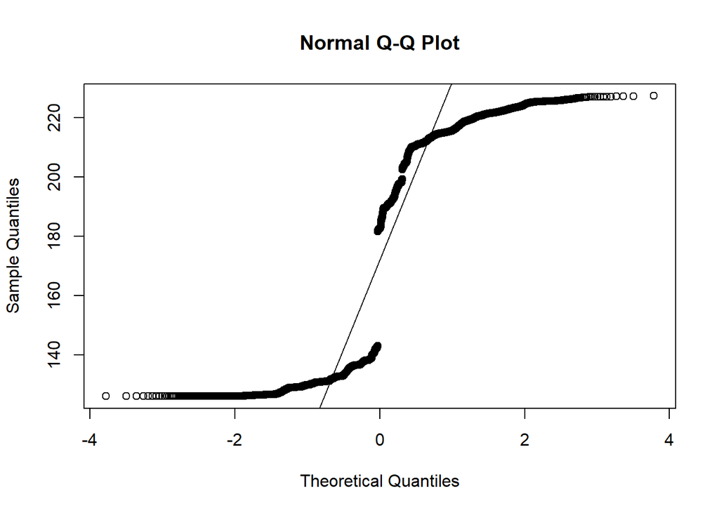

```r
qqnorm(data$CPI)
qqline(data$CPI)
```

```r
ks.test(data$CPI,'pnorm')
```

```
##
##  Asymptotic one-sample Kolmogorov-Smirnov test
##
## data:  data$CPI
## D = 1, p-value < 2.2e-16
## alternative hypothesis: two-sided
```

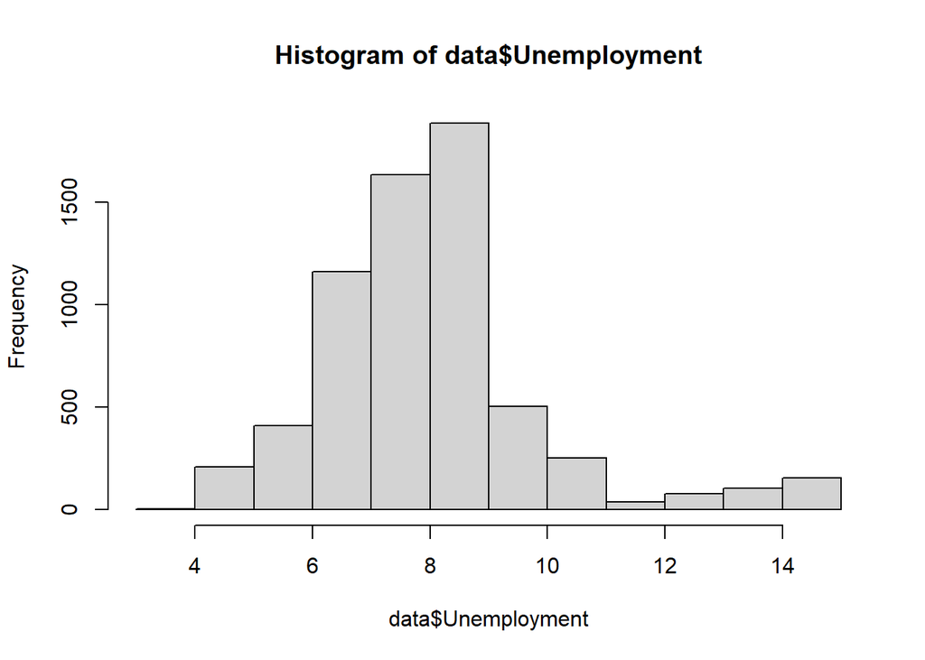

```r
hist(data$Unemployment)
```

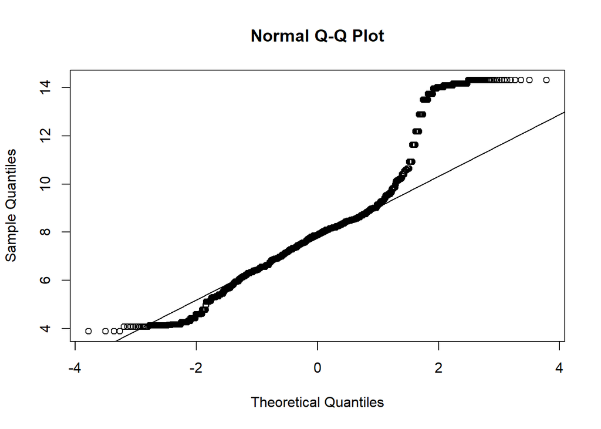

```r
qqnorm(data$Unemployment)
qqline(data$Unemployment)
```

```r
ks.test(data$Unemployment,'pnorm')
```

```
##
##  Asymptotic one-sample Kolmogorov-Smirnov test
##
## data:  data$Unemployment
## D = 0.99995, p-value < 2.2e-16
## alternative hypothesis: two-sided
```

Визуально можно предположить, что показатели уровня безработицы не подчиняются нормальному распределению. Тест Колмогорова-Смирнова: так как $p_{value}<2.2e−16$, что меньше, чем $α=0.05$, то предполагается, что показатели уровня безработицы не распределены нормально.

## Строим новый фрейм данных

Прологарифмируем переменные, распределение которых отличается от нормального

```r
d <- data
d$Weekly_Sales <- log(data$Weekly_Sales)
d$Temperature <- log(data$Temperature)
d$Fuel_Price <- log(data$Fuel_Price)
d$CPI <- log(data$CPI)
d$Unemployment <- log(data$Unemployment)
head(d)
```

```
##   Weekly_Sales Temperature Fuel_Price      CPI Unemployment
## 1     14.31245    3.745023  0.9446838 5.352315     2.092605
## 2     14.31140    3.650918  0.9353087 5.353005     2.092605
## 3     14.29297    3.687128  0.9218751 5.353228     2.092605
## 4     14.15891    3.842244  0.9403978 5.353372     2.092605
## 5     14.25686    3.839452  0.9650809 5.353516     2.092605
## 6     14.17984    4.056816  0.9809542 5.353661     2.092605
```

```r
is.na(d)
```

[output not shown]

[output cut: 6421 more lines]

Это привело к образованию NaN. (Преобразование данных квадратным корнем также было проведено, оно привело к тому, что возникло много значений FALSE)

## Выявление статистически аномальных значений

*Weekly Sales*

```r
grubbs.test(data$Weekly_Sales)
```

```
##
##  Grubbs test for one outlier
##
## data:  data$Weekly_Sales
## G = 4.91121, U = 0.99625, p-value = 0.002847
## alternative hypothesis: highest value 3818686.45 is an outlier
```

```r
test <- rosnerTest(data$Weekly_Sales, k=10); test
```

```
##
## Results of Outlier Test
## -------------------------
##
## Test Method:                     Rosner's Test for Outliers
##
## Hypothesized Distribution:       Normal
##
## Data:                            data$Weekly_Sales
##
## Sample Size:                     6435
##
## Test Statistics:                 R.1  = 4.911207
##                                  R.2  = 4.828520
##                                  R.3  = 4.806322
##                                  R.4  = 4.685911
##                                  R.5  = 4.550699
##                                  R.6  = 4.488466
##                                  R.7  = 4.493370
##                                  R.8  = 4.449433
##                                  R.9  = 4.387140
##                                  R.10 = 4.300639
##
## Test Statistic Parameter:        k = 10
##
## Alternative Hypothesis:          Up to 10 observations are not
##                                  from the same Distribution.
##
## Type I Error:                    5%
##
## Number of Outliers Detected:     7
##
##    i  Mean.i     SD.i   Value Obs.Num    R.i+1 lambda.i+1 Outlier
## 1  0 1046965 564366.6 3818686    1906 4.911207   4.468126    TRUE
## 2  1 1046534 563351.4 3766687    2764 4.828520   4.468093    TRUE
## 3  2 1046111 562373.2 3749058    1334 4.806322   4.468059    TRUE
## 4  3 1045691 561405.8 3676389     528 4.685911   4.468025    TRUE
## 5  4 1045282 560490.0 3595903    1763 4.550699   4.467992    TRUE
## 6  5 1044885 559630.1 3556766    1815 4.488466   4.467958    TRUE
## 7  6 1044495 558795.9 3555371    2816 4.493370   4.467924    TRUE
## 8  7 1044104 557960.9 3526713     476 4.449433   4.467891   FALSE
## 9  8 1043718 557144.1 3487987    1386 4.387140   4.467857   FALSE
## 10 9 1043337 556352.2 3436008     190 4.300639   4.467823   FALSE
```

```r
grubbs.test(data$Temperature)
```

```
##
##  Grubbs test for one outlier
##
## data:  data$Temperature
## G = 3.4006, U = 0.9982, p-value = 1
## alternative hypothesis: lowest value -2.06 is an outlier
```

Тест Граббса: так как $p_{value}=1 > α=0.05$, верна основная гипотеза: низшее значение -2.06 - неаномальное. Следовательно, и других аномальных значений нет.  
*Fuel Price*

```r
grubbs.test(data$Fuel_Price)
```

```
##
##  Grubbs test for one outlier
##
## data:  data$Fuel_Price
## G = 2.41687, U = 0.99909, p-value = 1
## alternative hypothesis: highest value 4.468 is an outlier
```

Тест Граббса: так как $p_{value}=1 > α=0.05$, верна основная гипотеза: высшее значение 4.468 - неаномальное. Следовательно, и других аномальных значений нет.  
*CPI*

```r
grubbs.test(data$CPI)
```

```
##
##  Grubbs test for one outlier
##
## data:  data$CPI
## G = 1.41410, U = 0.99969, p-value = 1
## alternative hypothesis: highest value 227.2328068 is an outlier
```

Тест Граббса: так как $p_{value}=1 > α=0.05$, верна основная гипотеза: высшее значение 227.2328068 - неаномальное. Следовательно, и других аномальных значений нет.  
*Unemployment*

```r
grubbs.test(data$Unemployment)
```

```
##
##  Grubbs test for one outlier
##
## data:  data$Unemployment
## G = 3.36580, U = 0.99824, p-value = 1
## alternative hypothesis: highest value 14.313 is an outlier
```

Тест Граббса: так как $p_{value}=1 > α=0.05$, верна основная гипотеза: высшее значение 14.313 - неаномальное. Следовательно, и других аномальных значений нет.

Убираем выбросы из столбца Weekly_Sales

```r
data1 <- data[-c(1906, 2764, 1334, 528, 1763, 1815, 2816),]
```

## Корреляционный анализ

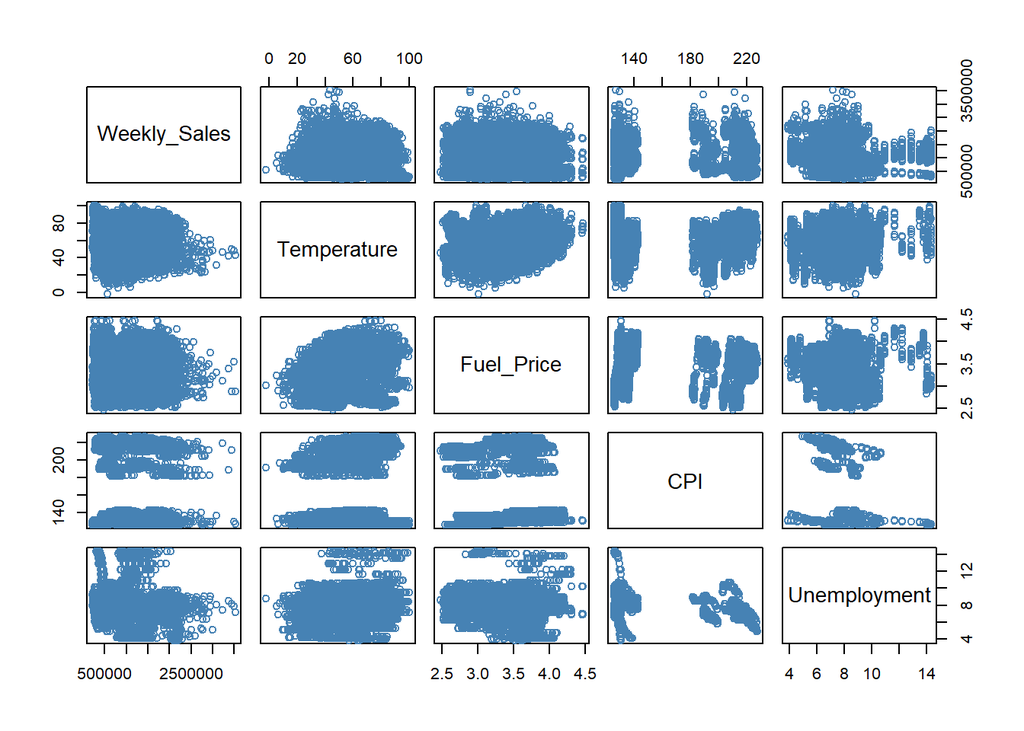

```r
pairs(data1, col = "steelblue")
```

```r
cor(data1)
```

```
##              Weekly_Sales Temperature  Fuel_Price         CPI Unemployment
## Weekly_Sales   1.00000000 -0.05765983  0.01192717 -0.07194561  -0.10584217
## Temperature   -0.05765983  1.00000000  0.14444566  0.17686694   0.10065339
## Fuel_Price     0.01192717  0.14444566  1.00000000 -0.17108517  -0.03486554
## CPI           -0.07194561  0.17686694 -0.17108517  1.00000000  -0.30248439
## Unemployment  -0.10584217  0.10065339 -0.03486554 -0.30248439   1.00000000
```

```r
round(cor(data1),3)
```

```
##              Weekly_Sales Temperature Fuel_Price    CPI Unemployment
## Weekly_Sales        1.000      -0.058      0.012 -0.072       -0.106
## Temperature        -0.058       1.000      0.144  0.177        0.101
## Fuel_Price          0.012       0.144      1.000 -0.171       -0.035
## CPI                -0.072       0.177     -0.171  1.000       -0.302
## Unemployment       -0.106       0.101     -0.035 -0.302        1.000
```

```r
round(cor(data1, method="spearman"),3)
```

```
##              Weekly_Sales Temperature Fuel_Price    CPI Unemployment
## Weekly_Sales        1.000      -0.069      0.026 -0.054       -0.062
## Temperature        -0.069       1.000      0.128  0.166        0.038
## Fuel_Price          0.026       0.128      1.000 -0.047       -0.065
## CPI                -0.054       0.166     -0.047  1.000       -0.389
## Unemployment       -0.062       0.038     -0.065 -0.389        1.000
```

*Анализ точечных диаграмм и корреляционной матрицы*  
По графикам можно предположить, что нет сильной корреляции между переменными. Это подтверждается корреляционной матрицей, так как максимальное значение корреляции между векторами в модуле 0,302. Все корреляции незначительны.

## Строим уравнение регрессии

```r
data1_RM <- lm(Weekly_Sales~ Temperature + Fuel_Price + CPI + Unemployment, data1)
data1_RM
```

```
##
## Call:
## lm(formula = Weekly_Sales ~ Temperature + Fuel_Price + CPI +
##     Unemployment, data = data1)
##
## Coefficients:
##  (Intercept)   Temperature    Fuel_Price           CPI  Unemployment
##    1717601.4        -695.9      -10343.1       -1572.0      -40847.9
```

```r
summary(data1_RM)
```

```
##
## Call:
## lm(formula = Weekly_Sales ~ Temperature + Fuel_Price + CPI +
##     Unemployment, data = data1)
##
## Residuals:
##     Min      1Q  Median      3Q     Max
## -946735 -477478 -112863  395659 2448268
##
## Coefficients:
##               Estimate Std. Error t value Pr(>|t|)
## (Intercept)  1717601.4    78743.8  21.813  < 2e-16 ***
## Temperature     -695.9      392.2  -1.774    0.076 .
## Fuel_Price    -10343.1    15580.9  -0.664    0.507
## CPI            -1572.0      193.2  -8.139 4.76e-16 ***
## Unemployment  -40847.9     3930.4 -10.393  < 2e-16 ***
## ---
## Signif. codes:  0 '***' 0.001 '**' 0.01 '*' 0.05 '.' 0.1 ' ' 1
##
## Residual standard error: 551500 on 6423 degrees of freedom
## Multiple R-squared:  0.02374,    Adjusted R-squared:  0.02313
## F-statistic: 39.05 on 4 and 6423 DF,  p-value: < 2.2e-16
```

```r
vif(data1_RM)
```

```
##  Temperature   Fuel_Price          CPI Unemployment
##     1.104618     1.081768     1.221302     1.149380
```

*Уравнение модели*:  
$Weekly Sales = 1717601.4-695.9Temperature-10343.1Fuel Price-1572.0CPI-40847.9Unemployment$

*Выводы по модели*:  
Все факторы влияют на объём еженедельных продаж отрицательно.  
С увеличением температуры на 1 градус объём продаж снижается в среднем на 695,9 долл. США. С увеличением цены топлива на 1 долл. США объём еженедельных продаж снижается в среднем на 10343.1 долл. США. С увеличением ИПЦ на 1 пункт объём продаж снижается в среднем на 1572 долл. США. С увеличением уровня безработицы на 1% объём продаж снижается в среднем на 40847,9 долл. США.  
Влияние температуры воздуха и цены на топливо является статистически не значимым. Влияние двух других факторов (ИПЦ и уровня безработицы) является статистически значимым.  
Модель объясняет примерно 2.374% изменчивости объёма еженедельных продаж.  
Модель объясняет 2.313% вариации зависимой переменной.  
По результатам Ф-статистики, модель в целом значима, то есть имеется связь между объёмом продаж и независимыми переменными, но, судя по значению Р квадрат, эта связь слабая.  
Результаты vif-анализа по всем переменным маленькие.Это позволяет утверждать, что независимые переменные (Temperature, Fuel_Price, CPI, Unemployment) вносят уникальный вклад в объяснение зависимой переменной и взаимно не зависят друг от друга в значительной степени.

## Строим новую модель

Мы убрали переменную Fuel Price, так как её влияние на объём продаж является наименее статистически значимым.

```r
data2_RM <- lm(Weekly_Sales~ Temperature + CPI + Unemployment, data1)
data2_RM
```

```
##
## Call:
## lm(formula = Weekly_Sales ~ Temperature + CPI + Unemployment,
##     data = data1)
##
## Coefficients:
##  (Intercept)   Temperature           CPI  Unemployment
##    1678292.7        -747.7       -1542.3      -40520.3
```

```r
summary(data2_RM)
```

```
##
## Call:
## lm(formula = Weekly_Sales ~ Temperature + CPI + Unemployment,
##     data = data1)
##
## Residuals:
##     Min      1Q  Median      3Q     Max
## -943903 -477302 -113520  396290 2451379
##
## Coefficients:
##               Estimate Std. Error t value Pr(>|t|)
## (Intercept)  1678292.7    51903.4  32.335  < 2e-16 ***
## Temperature     -747.7      384.4  -1.945   0.0518 .
## CPI            -1542.3      187.9  -8.208 2.69e-16 ***
## Unemployment  -40520.3     3899.1 -10.392  < 2e-16 ***
## ---
## Signif. codes:  0 '***' 0.001 '**' 0.01 '*' 0.05 '.' 0.1 ' ' 1
##
## Residual standard error: 551400 on 6424 degrees of freedom
## Multiple R-squared:  0.02367,    Adjusted R-squared:  0.02322
## F-statistic: 51.92 on 3 and 6424 DF,  p-value: < 2.2e-16
```

```r
vif(data2_RM)
```

```
##  Temperature          CPI Unemployment
##     1.060938     1.155956     1.131257
```

*Уравнение модели*:  
$Weekly Sales = 1678292.7-747.7Temperature-1542.3CPI-40520.3Unemployment$

*Выводы по модели*:  
Все факторы влияют на объём еженедельных продаж отрицательно.  
С увеличением температуры на 1 градус объём продаж снижается в среднем на 747.7 долл. США. С увеличением ИПЦ на 1 пункт объём продаж снижается в среднем на 1542.3 долл. США. С увеличением уровня безработицы на 1% объём продаж снижается в среднем на 40520.3 долл. США.  
Влияние температуры воздуха является чуть-чуть статистически не значимым. Влияние двух других факторов (ИПЦ и уровня безработицы) является статистически значимым.  
Модель объясняет примерно 2.367% изменчивости объёма еженедельных продаж.  
Модель объясняет 2.322% вариации зависимой переменной.  
По результатам Ф-статистики, модель в целом значима, то есть имеется связь между объёмом продаж и независимыми переменными, но, судя по значению Р квадрат, эта связь слабая.  
Результаты vif-анализа по всем переменным маленькие.Это позволяет утверждать, что независимые переменные (Temperature, СPI, Unemployment) вносят уникальный вклад в объяснение зависимой переменной и взаимно не зависят друг от друга в значительной степени.

**Так как в новой модели значение Р квадрата снизилось, предполагаю, что лучше оставить первую модель**

## Пошаговая регрессия

```r
fit <- lm(Weekly_Sales~ Temperature + Fuel_Price + CPI + Unemployment, data1)
k <- ols_step_all_possible(fit);k
```

```
##    Index N                              Predictors     R-Square Adj. R-Square
## 4      1 1                            Unemployment 0.0112025658  1.104869e-02
## 3      2 1                                     CPI 0.0051761705  5.021358e-03
## 1      3 1                             Temperature 0.0033246563  3.169556e-03
## 2      4 1                              Fuel_Price 0.0001422574 -1.333826e-05
## 10     5 2                        CPI Unemployment 0.0230989838  2.279489e-02
## 7      6 2                Temperature Unemployment 0.0134347879  1.312769e-02
## 9      7 2                 Fuel_Price Unemployment 0.0112704953  1.096272e-02
## 6      8 2                         Temperature CPI 0.0072605305  6.951507e-03
## 8      9 2                          Fuel_Price CPI 0.0051763205  4.866648e-03
## 5     10 2                  Temperature Fuel_Price 0.0037437003  3.433582e-03
## 13    11 3            Temperature CPI Unemployment 0.0236741342  2.321819e-02
## 14    12 3             Fuel_Price CPI Unemployment 0.0232625597  2.280642e-02
## 12    13 3     Temperature Fuel_Price Unemployment 0.0136733103  1.321270e-02
## 11    14 3              Temperature Fuel_Price CPI 0.0073240221  6.860444e-03
```

[output cut: 17 more lines]

## Анализ остатков модели

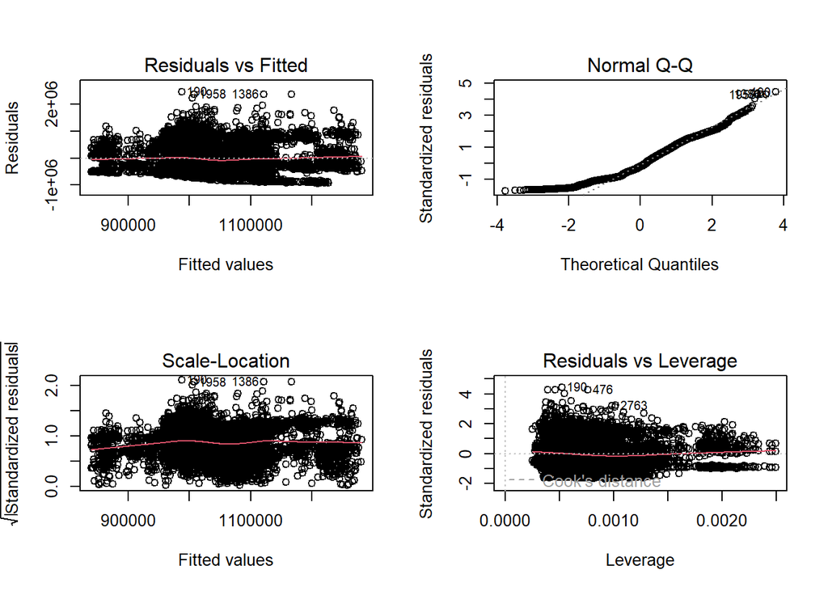

```r
par(mfrow = c(2, 2))
plot(data1_RM)
```

```r
describe(data1_RM$resid)
```

```
##    vars    n mean       sd    median   trimmed      mad       min     max
## X1    1 6428    0 551297.8 -112863.3 -36012.37 600125.8 -946735.1 2448268
##      range skew kurtosis     se
## X1 3395003 0.57    -0.35 6876.2
```

```r
hist(data1_RM$resid)

qqnorm(data1_RM$resid)
qqline(data1_RM$resid)

ks.test(data1_RM$resid, 'pnorm')
```

```
##
##  Asymptotic one-sample Kolmogorov-Smirnov test
##
## data:  data1_RM$resid
## D = 0.55849, p-value < 2.2e-16
## alternative hypothesis: two-sided
```

```r
describe(data1_RM$resid)
```

```
##    vars    n mean       sd    median   trimmed      mad       min     max
## X1    1 6428    0 551297.8 -112863.3 -36012.37 600125.8 -946735.1 2448268
##      range skew kurtosis     se
## X1 3395003 0.57    -0.35 6876.2
```

```r
DescTools::RunsTest(data1_RM$resid) #Тестируем остатки на независимость
```

```
##
##  Runs Test for Randomness
##
## data:  data1_RM$resid
## z = -72.31, runs = 316, m = 3214, n = 3214, p-value < 2.2e-16
## alternative hypothesis: true number of runs is not equal the expected number
## sample estimates:
## median(x)
## -112863.3
```

```r
durbinWatsonTest(data1_RM) #Тестируем остатки на автокорреляцию
```

```
##  lag Autocorrelation D-W Statistic p-value
##    1       0.9482568     0.1032487       0
##  Alternative hypothesis: rho != 0
```

```r
ncvTest(data1_RM) #Тестируем остатки на гомоскедактичность
```

```
## Non-constant Variance Score Test
## Variance formula: ~ fitted.values
## Chisquare = 28.54864, Df = 1, p = 9.1374e-08
```

[figure not shown]

## Проверяем выполнение предпосылок

1. Переменные модели должны иметь распределение, близкое к нормальному. - не выполняется (если учесть закон больших чисел, то данные следуют нормальному распределению).
2. Зависимая и независимые переменные должны быть измерены в метрической шкале.
3. Для построения линейных регрессий, зависима и независимые переменные должны иметь линейную связь.
4. Отсутствие мультиколлинеарности – независимость между собой переменных-предикторов, отсутствие высокой корреляции (для множественной регрессии).
5. Отсутствие автокорреляции – отсутствие независимости остатков.- не выполняется.
6. Гомоскедастичность - не выполняется.

## Прогноз по модели

```r
pred <- predict(data1_RM); pred
```

[output not shown]

[output cut: 1553 more lines]

[output not shown]

```r
pred.ci <- predict(data1_RM, interval = 'confidence', level = 0.95);pred.ci
```

```
##            fit       lwr       upr
## 1     998597.0  967013.9 1030180.2
## 2    1001260.7  967930.2 1034591.1
## 3    1000550.2  967144.7 1033955.7
## 4     995353.3  964781.7 1025924.9
## 5     994733.9  965272.8 1024195.0
## 6     986394.3  959620.0 1013168.7
## 7     988339.5  962258.1 1014420.9
## 8     990704.3  964309.8 1017098.8
## 9     995791.9  970360.2 1021223.7
## 10    993076.6  968357.6 1017795.6
## 11    992574.3  968528.6 1016620.0
## 12    993816.7  969711.9 1017921.6
## 13    992261.2  967542.2 1016980.3
## 14    988193.1  963379.8 1013006.5
```

[output cut: 6414 more lines]

```r
pred.pi <- predict(data1_RM, interval = 'prediction', level = 0.95);pred.pi
```

```
##            fit           lwr     upr
## 1     998597.0 -8.292815e+04 2080122
## 2    1001260.7 -8.031697e+04 2082838
## 3    1000550.2 -8.102971e+04 2082130
## 4     995353.3 -8.614280e+04 2076849
## 5     994733.9 -8.673141e+04 2076199
## 6     986394.3 -9.500113e+04 2067790
## 7     988339.5 -9.303901e+04 2069718
## 8     990704.3 -9.068180e+04 2072090
## 9     995791.9 -8.557110e+04 2077155
## 10    993076.6 -8.826990e+04 2074423
## 11    992574.3 -8.875700e+04 2073906
## 12    993816.7 -8.751592e+04 2075149
## 13    992261.2 -8.908529e+04 2073608
## 14    988193.1 -9.315554e+04 2069542
```

[output cut: 6414 more lines]

## Bыводы и дальнейшие перспективы исследования

*Р.S. Выбор пал на эту базу данных, так как тема моей дипломной работы “Особенности функционирвания операционного менеджмента в ТНК (на примере Walmart)”*

## Список литературы

1. Walmart Sales. (2024b, February 13). Kaggle. https://www.kaggle.com/datasets/9592bb3b3c89493fabab56b4317ae10dbd70e6b66d2d464fb7f08c6a5903556d/data
2. Презентации к занятию. ВОЗМОЖНОСТИ ПРОВЕДЕНИЯ МНОГОМЕРНОГО ЛИНЕЙНОГО РЕГРЕССИОННОГО АНАЛИЗА В R.
3. Gnanasundaram, S. (2023, March 30). Importance of Regression Analysis in sales forecasting. Lystloc. https://www.lystloc.com/blog/importance-of-regression-analysis-in-sales-forecasting/\
4. Регрессионный анализ влияния объема продаж на показатели деятельности компании ООО «Роберт Бош Самара». (n.d.). https://cyberleninka.ru/article/n/regressionnyy-analiz-vliyaniya-obema-prodazh-na-pokazateli-deyatelnosti-kompanii-ooo-robert-bosh-samara/viewer\
5. Chemutai, P. (2023, September 17). Analysis of External Factors that Impact Sales of a Retail Store- A Regression Analysis. Medium. https://medium.com/@phinmaiyo/analysis-of-external-factors-that-impact-sales-of-a-retail-store-a-regression-analysis-f7445bbf3e86
6. https://medium.com/@farizalfitraaa/regression-analysis-on-walmart-sales-analyzing-the-impact-of-cpi-and-holiday-d68586a728b7\
7. Sales Prediction of Walmart Based on Regression Models. Jiayuan Zhang
8. Walmart Sales. (2024c, February 13). Kaggle. https://www.kaggle.com/datasets/9592bb3b3c89493fabab56b4317ae10dbd70e6b66d2d464fb7f08c6a5903556d/code
9. Rivaldi, M. (2022, October 15). Walmart Sales Analysis - M Rivaldi - Medium. Medium. https://medium.com/@rivaldi165/walmart-sales-analysis-453cee84042d
10. Mohamedaboulfath. (2024, March 1). Walmart sales data analysis. Kaggle. https://www.kaggle.com/code/mohamedaboulfath/walmart-sales-data-analysis